# Differential gene expression analysis

Mari-Lee Odendaal

2022-02-04 16:51:29

## Load R-packages

```r
library(tximport);library(DESeq2);library(csaw);library(pheatmap);library(tidyverse);library(here);library(glue);library(DEFormats);library(colorspace);library(edgeR)
```

## Input files

```r
dir = here::here("input", "adult")
samples <- read.table(file.path(dir, "samplesheet.txt"), header = TRUE)
files <- file.path(dir, "Salmon", samples$File)
names(files) <- paste0("D", 7:12, ".tabular")
tx2gene <- read.table(file.path(dir, "gene_trans_map")) %>% .[,c(2,1)]
txi <- tximport(files, type = "salmon", tx2gene = tx2gene)
sample_tb <- data.frame(condition = factor(samples$Condition))
rownames(sample_tb) <- colnames(txi$counts)
dds <- DESeqDataSetFromTximport(txi, sample_tb, ~condition)
```

Salmon files are imported to summarize the abundances, counts, and transcript lengths to gene-level.

## Filter lowly expressed genes

```r
keep <- rowSums(cpm(dds)>=0.5) >= 2
dds <- dds[keep,]
```

Genes with an expression lower than 0.5 counts per million in at least 2 of the samples are removed from the data.

## Differential gene expression analysis with DESeq

```r
dds <- DESeq(dds)
```

```r
res_pvsp <- results(dds, contrast=c("condition","Present","Past"), pAdjustMethod = "BH", alpha = 0.05, lfcThreshold = 0.5)
```

The differential gene expression analysis is performed for the comparison present vs past using a log2 fold change threshold of 0.5.

```r
res_fvsp <- results(dds, contrast=c("condition","Future","Present"), pAdjustMethod = "BH", alpha = 0.05, lfcThreshold = 0.5)
```

The differential gene expression analysis is performed for the comparison future vs present using a log2 fold change threshold of 0.5.

## Pre-processing for visualization of the DE genes

```r
res_pvsp$padj[is.na(res_pvsp$padj)] <- 1
keep <- res_pvsp$padj < 0.05
res_pvsp_sig <- res_pvsp[keep,] %>% as.data.frame()
res_pvsp_sig$gene <- rownames(res_pvsp_sig)

res_fvsp$padj[is.na(res_fvsp$padj)] <- 1
keep <- res_fvsp$padj < 0.05
res_fvsp_sig <- res_fvsp[keep,] %>% as.data.frame()
res_fvsp_sig$gene <- rownames(res_fvsp_sig)

res_all <- merge(res_pvsp_sig, res_fvsp_sig, by = "gene", all = T)
```

## Filter genes with extreme within group variation

```r
df <- rownames_to_column(as.data.frame(counts(dds)), var = "gene") %>% as_tibble() %>% pivot_longer(c(2:7), names_to = "condition") %>% mutate(condition = ifelse(condition == samples$File, samples$Condition, NA)) %>% group_by(gene, condition) %>% summarise(diff = max(value)-min(value), fold = max(value)/min(value))

genes_rm <- unique(df[(df$diff > 300) & df$fold > 20,]$gene)
dds <- dds[!rownames(as.data.frame(cpm(dds))) %in% genes_rm,]
```

Genes with a high variation within groups are removed from the data.

```r
saveRDS(cpm(dds), file = "cpm_adults.RDS")
```

The filtered dataset is normalized by implementing counts per million, this is used for the correlation analysis

## Visualization of the DE genes

```r
y = as.DGEList(dds)
se <- SummarizedExperiment(assays = list(counts = y$counts, offset = y$offset))
se$totals <- y$samples$lib.size
cpms <- calculateCPM(se, use.offsets = TRUE, log = T)
```

The filtered data is normalized by implementing counts per million taking into account the offset and library size.

```r
cpms_sig <- subset(cpms, rownames(cpms) %in% res_all$gene)
colnames(cpms_sig) <- c("Future S1","Future S2","Past S1","Past S2","Present S1","Present S2")
cpms_sig2 <- t(scale(t(cpms_sig)))
cpms_sig2 <- cpms_sig2[,c(3,4,5,6,1,2)]
```

Rows are scaled for visualization

```r
col <- rev(diverging_hcl(15, "Red-Green"))
```

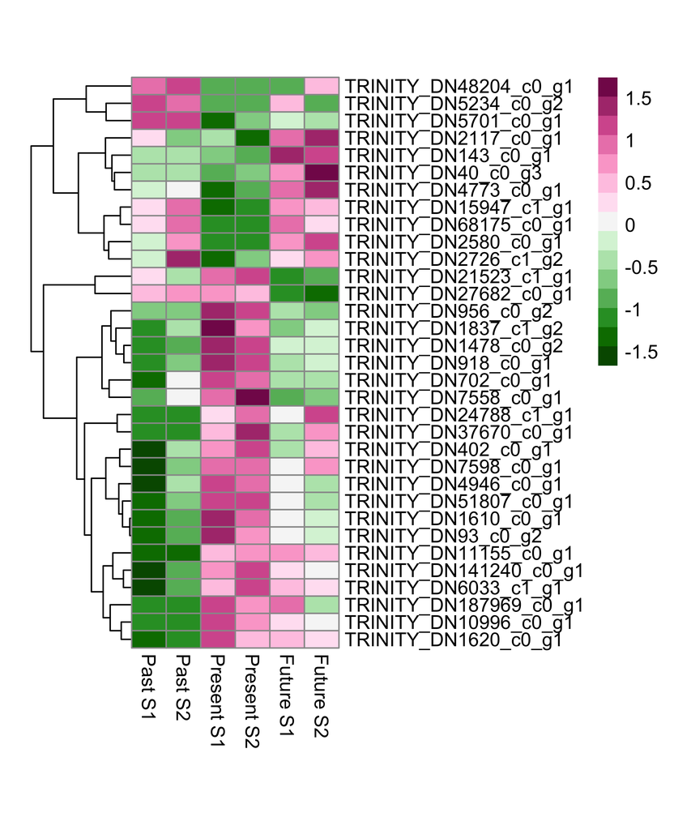

```r
hm_all <- pheatmap(cpms_sig2, col=col, show_rownames = T, cluster_cols = F,cellwidth = 18, cellheight = 9)
```

## Pre-processing for GO MWU analysis

```r
res_pvsp2 = subset(res_pvsp, select = c(log2FoldChange,pvalue)) %>% as.data.frame()
res_pvsp2 <- res_pvsp2[!rownames(res_pvsp2) %in% genes_rm,]

res_pvsp2 <- res_pvsp2 %>% mutate(
  direction = sqrt(log2FoldChange*log2FoldChange)/log2FoldChange*-1,
  direction = ifelse(is.na(direction), 0, direction),
  gene = rownames(.),
  logp = log(pvalue,10)*direction) %>%
  subset(., select = c(gene, logp))
```

```r
res_fvsp2 = subset(res_fvsp, select = c(log2FoldChange,pvalue)) %>% as.data.frame()
res_fvsp2 <- res_fvsp2[!rownames(res_fvsp2) %in% genes_rm,]

res_fvsp2 <- res_fvsp2 %>% mutate(
  direction = sqrt(log2FoldChange*log2FoldChange)/log2FoldChange*-1,
  direction = ifelse(is.na(direction), 0, direction),
  gene = rownames(.),
  logp = log(pvalue,10)*direction) %>%
  subset(., select = c(gene, logp))
```

```r
write.table(res_pvsp2, file = "pvsp_adult.csv", append = FALSE, sep = ",", dec = ".", row.names = F, col.names = T)

write.table(res_fvsp2, file = "fvsp_adult.csv", append = FALSE, sep = ",", dec = ".", row.names = F, col.names = T)
```

All the genes with their log transformed P-value are used in the GO-MWU analysis (https://github.com/z0on/GO_MWU).

*The same script was implemented for the juveniles